# Raport sprzedazowy

Trendy, skutecznosc promocji i prognozy

Zespol analityczny

08.06.2026

> Niniejszy raport przedstawia analize sprzedazy detalicznej: jakosc danych, dynamike obrotow, wplyw promocji oraz prognoze na kolejne 30 dni. Wszystkie wyniki wygenerowano automatycznie na podstawie biezacych danych transakcyjnych.

# Jakosc i kompletnosc danych

Zanim przejdziemy do analizy, weryfikujemy wiarygodnosc danych zrodlowych: braki, duplikaty, wartosci nietypowe oraz kompletnosc historii.

| Wskaznik | Wartosc |
| --- | --- |
| Liczba rekordow | 1 702 704 |
| Braki w datach | 0 |
| Braki w sprzedazy | 0 |
| Duplikaty klucza | 0 |
| Sprzedaz ujemna | 0 |
| Luki w kalendarzu | tak |
| Liczba szeregow (sklep-kategoria) | 1 782 |
| Kompletnosc panelu | 99.7% |

Analizowany okres: **01.01.2015** – **15.08.2017** (958 dni).

# Dynamika sprzedazy

Kluczowe wskazniki opisujace poziom i zmiennosc sprzedazy w analizowanym okresie.

Kluczowe wskazniki sprzedazy

| Wskaznik | Wartosc |
| --- | --- |
| Sprzedaz calkowita | 723 301 233 |
| Srednia dzienna | 756 591 |
| Mediana dzienna | 731 177 |
| Odchylenie standardowe | 203 480 |
| Wspolczynnik zmiennosci | 0.27 |
| Udzial dni z promocja | 100% |
| Sr. produktow na promocji/dzien | 7684.8 |
| Sr. odstep miedzy szczytami (dni) | 3.7 |

Wykres ponizej przedstawia sprzedaz dzienna wraz z linia trendu, ktora wygladza wahania i uwidacznia kierunek zmian.

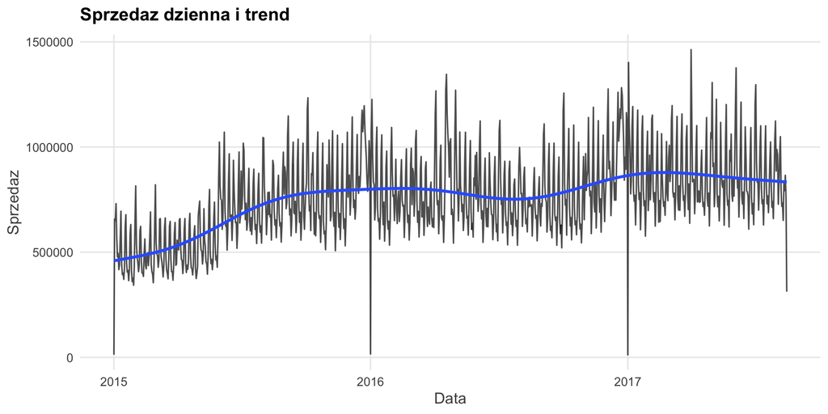

Podzial wedlug typu sklepu pokazuje, ktore formaty handlowe generuja najwiekszy obrot.

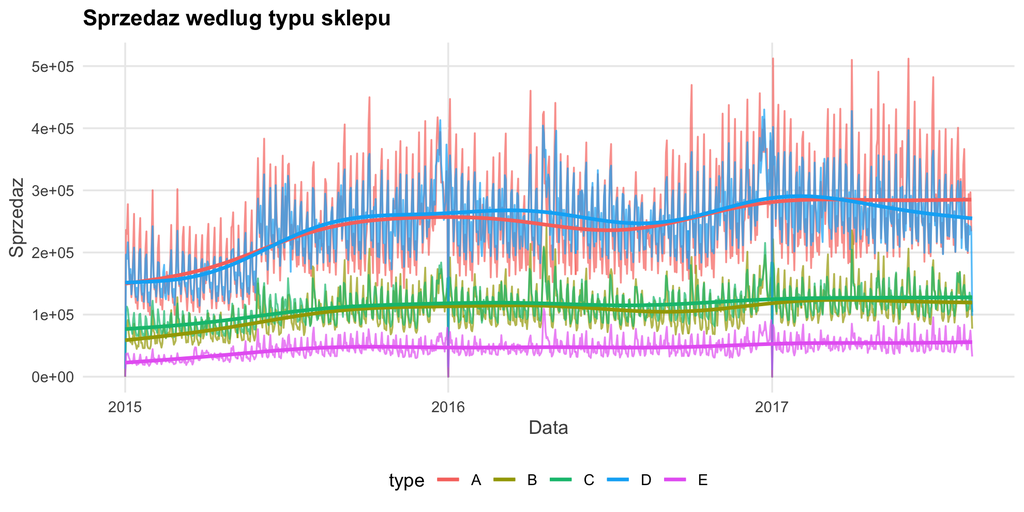